# Mijn Portfolio

Welkom bij mijn portfolio. Dit project bevat meerdere analises in R.

# 1 Profiel

Gemotiveerde Life Sciences student met interesse in bioinformatica, RNA-sequencing en data-analyse.

# 2 Opleiding

## 2.1 HBO Life Sciences

Hogeschool … 2021 – heden

# 3 Skills

- RStudio
- R Markdown
- DESeq2
- PCA analyse
- RNA-seq analyse
- FastQC
- FeatureCounts
- Data visualisatie
- Excel
- Teamwork
- Probleemoplossend denken

# 4 Werkervaring

## 4.1 Transactional opperator

2025 – heden

# 5 stageplek solicitatie

# 6 skills benoemen - datascience for biology skills

# 7 geen persoonsgegevens

Tijdens mijn studie heb ik interesse gekregen in data science en bio-informatica. Over één à twee jaar zou ik graag willen werken binnen een organisatie waar data-analyse een belangrijke rol speelt, bijvoorbeeld binnen een data science bedrijf, onderzoeksinstelling of een biologisch/life science georiënteerd bedrijf. Mijn ideale baan zou een functie zijn waarin ik kan helpen met het verwerken, analyseren en visualiseren van datasets om informatie en inzichten uit data te halen.

Op dit moment heb ik door de minor Data Science for Biology een basis ontwikkeld in verschillende data science vaardigheden. Ik heb ervaring opgedaan met programmeertalen zoals R, het werken met datasets, data visualisatie, reproduceerbaar werken met RMarkdown, versiebeheer met Git en GitHub en basiskennis van SQL. Daarnaast heb ik geleerd hoe belangrijk gestructureerd werken, documentatie en reproduceerbaarheid zijn binnen data science projecten.

Hoewel ik nog aan het begin van mijn ontwikkeling sta, denk ik dat deze vaardigheden een goede basis vormen om later mee te kunnen werken aan data science projecten binnen een professioneel team. Ik merk vooral dat ik het interessant vind om met data te werken en om analyses overzichtelijk en reproduceerbaar uit te voeren.

In de toekomst zou ik mij verder willen ontwikkelen in meer geavanceerde data science technieken. Denk hierbij aan machine learning, statistische modellering, het werken met grotere databases en het analyseren van biologische datasets zoals sequencing data. Daarnaast lijkt het mij waardevol om mijn programmeervaardigheden verder uit te breiden en meer ervaring op te doen met samenwerken binnen grotere projecten.

Door deze skills verder te ontwikkelen hoop ik uiteindelijk een rol te kunnen vervullen waarin ik data science kan combineren met biologie en onderzoek.

in deze vrije ruimte opdracht leer ik het volgende: - data preprocessing van images - image classification model in Keras - verschil tussen datasets - model generalization

```r
# run de install.packages maar 1 keer in de console
install.packages("reticulate")
install.packages("tensorflow")
install.packages("keras3")
```

```r
reticulate::install_python()
reticulate::py_install("tensorflow")
```

```r
py_config()
```

```
## python:         /home/dani.pfeijffer/.cache/R/reticulate/uv/cache/archive-v0/2rx-ZnuAYij6YPTE/bin/python
## libpython:      /home/dani.pfeijffer/.cache/R/reticulate/uv/python/cpython-3.12.13-linux-x86_64-gnu/lib/libpython3.12.so
## pythonhome:     /home/dani.pfeijffer/.cache/R/reticulate/uv/cache/archive-v0/2rx-ZnuAYij6YPTE:/home/dani.pfeijffer/.cache/R/reticulate/uv/cache/archive-v0/2rx-ZnuAYij6YPTE
## virtualenv:     /home/dani.pfeijffer/.cache/R/reticulate/uv/cache/archive-v0/2rx-ZnuAYij6YPTE/bin/activate_this.py
## version:        3.12.13 (main, May 10 2026, 19:30:01) [Clang 22.1.3 ]
## numpy:          /home/dani.pfeijffer/.cache/R/reticulate/uv/cache/archive-v0/2rx-ZnuAYij6YPTE/lib/python3.12/site-packages/numpy
## numpy_version:  2.4.6
## keras:          /home/dani.pfeijffer/.cache/R/reticulate/uv/cache/archive-v0/2rx-ZnuAYij6YPTE/lib/python3.12/site-packages/keras
##
## NOTE: Python version was forced by py_require()
```

```r
# data downloaden
fashion_mnist <- dataset_fashion_mnist()
c(train_images, train_labels) %<-% fashion_mnist$train
c(test_images, test_labels) %<-% fashion_mnist$test

# Vector maken met namen van verschillende klassificaties
class_names = c('T-shirt/top',
                'Trouser',
                'Pullover',
                'Dress',
                'Coat',
                'Sandal',
                'Shirt',
                'Sneaker',
                'Bag',
                'Ankle boot')


dim(train_images)
```

```
## [1] 60000    28    28
```

```r
dim(train_labels)
```

```
## [1] 60000
```

```r
train_labels[1:20]
```

```
##  [1] 9 0 0 3 0 2 7 2 5 5 0 9 5 5 7 9 1 0 6 4
```

```r
dim(test_images)
```

```
## [1] 10000    28    28
```

```r
dim(test_labels)
```

```
## [1] 10000
```

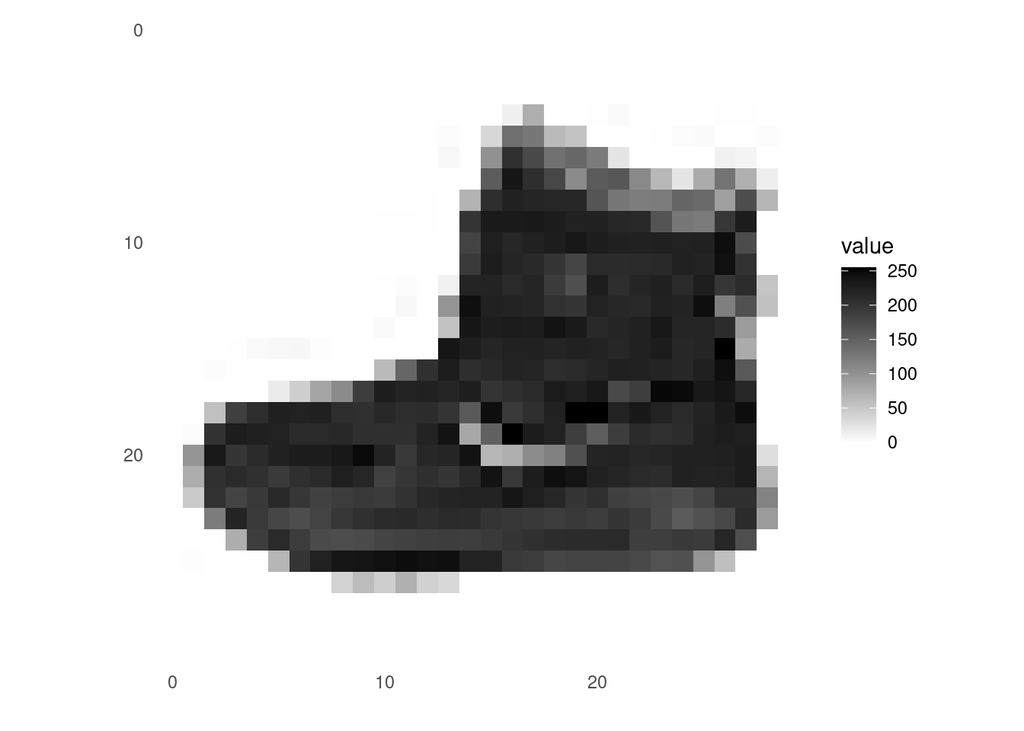

```r
image_1 <- as.data.frame(train_images[1, , ])
colnames(image_1) <- seq_len(ncol(image_1))
image_1$y <- seq_len(nrow(image_1))
image_1 <- gather(image_1, "x", "value", -y)
image_1$x <- as.integer(image_1$x)

ggplot(image_1, aes(x = x, y = y, fill = value)) +
  geom_tile() +
  scale_fill_gradient(low = "white", high = "black", na.value = NA) +
  scale_y_reverse() +
  theme_minimal() +
  theme(panel.grid = element_blank())   +
  theme(aspect.ratio = 1) +
  xlab("") +
  ylab("")
```

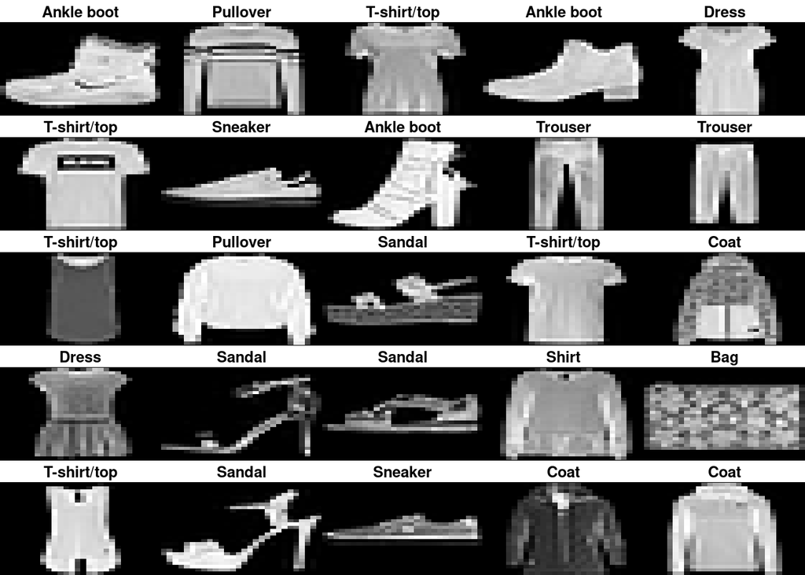

```r
# schaal pixelwaarden tussen 0 en 1
train_images <- train_images / 255
test_images <- test_images / 255


par(mfcol=c(5,5))
par(mar=c(0, 0, 1.5, 0), xaxs='i', yaxs='i')
for (i in 1:25) {
  img <- train_images[i, , ]
  img <- t(apply(img, 2, rev))
  image(1:28, 1:28, img, col = gray((0:255)/255), xaxt = 'n', yaxt = 'n',
        main = paste(class_names[train_labels[i] + 1]))
}
```

```r
# Bouw een netwerkmodel met meerdere lagen voor image clasificatie
model <- keras_model_sequential()
model %>%
  layer_flatten(input_shape = c(28, 28)) %>%
  layer_dense(units = 128, activation = 'relu') %>%
  layer_dense(units = 10, activation = 'softmax')
```

```r
# Kijken hoe de neurale netwerk is gemaakt.
# summary(model)

# leerproces van de model instellen (zoals bepalen wat fout is, en hoe de prestaties worden gemeten).
model %>% compile(
  optimizer = 'adam',
  loss = 'sparse_categorical_crossentropy',
  metrics = c('accuracy')
)
```

```r
# met deze code word het trainen van de model gestart.
# je voedt het model met de data van train_images en train_labels arrays.
# epochs hier staat voor de hoeveelheid keren dat het model de data opnieuw leert. hier is gekozen voor een epoch van 5.
# het voordeel van een hogere epoch is dat het model acurater word. maar als je een te hoge epoch hebt dan leert het model te specifiek waardoor je het eigenlijk traint om de test data te herkennen ten opzichte van nieuwe data.
# een te lage epoch is natuurlijk ook niet goed omdat je model dan hellemaal niet specifiek word voor het gene wat je wilt identificeren.
# het model kijkt naar hoe acuraat het is en hoe fout het is. dit word gedaan door de statistiek accuracy en loss respectievelijk.
# accuracy voor het model is hoe goed het model is om een plaatje te herkennen uitgedrukt in procenten.
# loss voor het model is hoe ver van het goede antwoord vandaan zit. dus eigenlijk hoe groot de fout is. uitgedrukt in procentn.
model %>% fit(train_images, train_labels, epochs = 5, verbose = 2)
```

```
## 1875/1875 - 5s - 2ms/step - accuracy: 0.8243 - loss: 0.4961
## 1875/1875 - 4s - 2ms/step - accuracy: 0.8672 - loss: 0.3699
## 1875/1875 - 4s - 2ms/step - accuracy: 0.8790 - loss: 0.3321
## 1875/1875 - 4s - 2ms/step - accuracy: 0.8858 - loss: 0.3094
## 1875/1875 - 4s - 2ms/step - accuracy: 0.8921 - loss: 0.2916
```

```r
# nu we het model getraint hebben gaan we kijken naar de tsest data set. en wat de accuracy/loss daarvan is.
score <- model %>% evaluate(test_images, test_labels, verbose = 0)


cat("Test loss:", score[["loss"]], "\n")
```

```
## Test loss: 0.3632389
```

```r
cat("Test accuracy:", score[["accuracy"]], "\n")
```

```
## Test accuracy: 0.8721
```

```r
# nu we een getrained model hebben en de acuratie/loss hebben verkregen kunnen we een voorspellingen doen met test data.
# deze  code gaat langs alle test afbeeldingen en geeft voor elke afbeelding 10 keer een 10 cijferig getal van 0 tot 1.
# voor elke optie van de afbeelding geeft hij een cijfer wat de confidence weer geeft. hoe hoger het cijfer bij de 1 is hoe zekerder de model is dat dat is wat de afbeelding is.
predictions <- model %>% predict(test_images)
```

```
## 313/313 - 0s - 1ms/step
```

```r
# na alle voorspellingen te hebben gedaan word hier gekeken naar de voorspellingen van de eerste afbeelding. voor elke mogelijke optie word een confidence cijfer gegeven.
predictions[1, ]
```

```
##  [1] 2.219157e-06 1.021509e-07 1.823904e-07 3.620709e-09 6.272699e-07
##  [6] 3.558503e-03 1.657251e-06 3.097821e-02 1.815146e-07 9.654582e-01
```

```r
# om te zien welke label het hoogste confidence heeft word de which.max gebruikt. en hieruit is te zien dat positie 10 de hoogste confidence heeft
which.max(predictions[1, ])
```

```
## [1] 10
```

```r
# met test_abels[1] word gekeken welk label de eerste afbeelding heeft. en hieruit komt 9, wat correleert met ankle boot uit de class_names array.
# class_names <- c(
#  'T-shirt/top',  # 0
#  'Trouser',      # 1
#  'Pullover',     # 2
#  'Dress',        # 3
#  'Coat',         # 4
#  'Sandal',       # 5
#  'Shirt',        # 6
#  'Sneaker',      # 7
#  'Bag',          # 8
#  'Ankle boot'    # 9
#)
test_labels[1]
```

```
## [1] 9
```

[figure not shown]

```r
# Hier worden 25 afbeeldingen geprint met daarboven de voorspelling van het model in het groen als dit correct was en in het rood als hij het mis had.
# ook word hier gecorigeerd voor de vector positie van class_names, angezien vectors altijd beginnen met positie 0. door de which.max te corrigeren met -1 komt hier de correcte label naam uit met de hoogste confidence.
par(mfcol=c(5,5))
par(mar=c(0, 0, 1.5, 0), xaxs='i', yaxs='i')
for (i in 1:25) {
  img <- test_images[i, , ]
  img <- t(apply(img, 2, rev))
  # subtract 1 as labels go from 0 to 9
  predicted_label <- which.max(predictions[i, ]) - 1
  true_label <- test_labels[i]
  if (predicted_label == true_label) {
    color <- '#008800'
  } else {
    color <- '#bb0000'
  }
  image(1:28, 1:28, img, col = gray((0:255)/255), xaxt = 'n', yaxt = 'n',
        main = paste0(class_names[predicted_label + 1], " (",
                      class_names[true_label + 1], ")"),
        col.main = color)
}
```

```r
# We kunnen ook selecteren op 1 afbeelding tegelijk.
# hiervoor moet wel gelet worden op de dimensies die nodig zijn voor het model. het model verwacht een 3d model namelijk.
# 'drop = FALSE' behoud de batch dimensie waardoor de afbeelding niet 'plat' word als het ware.
img1 <- test_images[1, , , drop = FALSE]
img34 <- test_images[34, , , drop = FALSE]
img77 <- test_images[77, , , drop = FALSE]

# met dim(img) zie je dat je 1,28,28 krijgt. waarbij de 1 de afbeelding is, en beide 28 staan voor de hoogte en breedte van de afbeelding.
dim(img1)
```

```
## [1]  1 28 28
```

```r
dim(img34)
```

```
## [1]  1 28 28
```

```r
dim(img77)
```

```
## [1]  1 28 28
```

```r
# hier word de voorspelling gemaakt voor afbeelding 1 in de variabel predictions
predictions <- model %>% predict(img1)
```

```
## 1/1 - 0s - 32ms/step
```

```r
# vervolgens kan je hiermee de voorspellingen per label zien.
prediction <- predictions[1, ]
prediction
```

```
##  [1] 2.219162e-06 1.021507e-07 1.823906e-07 3.620702e-09 6.272711e-07
##  [6] 3.558503e-03 1.657251e-06 3.097820e-02 1.815146e-07 9.654583e-01
```

```r
# en met de which.max() -1, krijg je gelijk de juiste label nummer terug die hoort bij de afbeelding.
which.max(predictions[1, ]) - 1
```

```
## [1] 9
```

## 7.1 Mapstructuur van R

[figure not shown]

Mapstructuur

## 7.2 README van R

[figure not shown]

README

## 7.3 README van Github

[figure not shown]

READMEPortfolio

De mapstructuur van de Github zelf is niet te doen vanwegen de grote dataset die ik heb gedownload met te veel afbeeldingen.

```r
# run de install.packages maar 1 keer in de console
install.packages("remotes")
remotes::install_github("nyiuab/NBZIMM")
```

```r
# Lees de data in in R met het readxl package.

data <- read_excel("~/Workflows/Workflows_Portfolio/Opdracht_4_Reproducible_Science/CE.LIQ.FLOW.062_Tidydata.xlsx")
# View(data)
```

```r
# Inspecteer de data. Is de data goed ingelezen? Kloppen de data types voor rawData, compName en compConcentration?

## RawData hoort numeriek te zijn
## compName hoort tekst/factor te zijn
## compConcentration hoort numeriek of factor te zijn afhankelijk van de analyse

class(data$RawData)
```

```
## [1] "numeric"
```

```r
class(data$compName)
```

```
## [1] "character"
```

```r
class(data$compConcentration)
```

```
## [1] "character"
```

```r
unique(data$compConcentration)
```

```
##  [1] "4.99"                  "0.499"                 "4.99E-2"
##  [4] "4.9899999999999996E-3" "4.9899999999999999E-4" "4.99E-5"
##  [7] "19.5"                  "1.95"                  "0.19500000000000001"
## [10] "1.95E-2"               "1.9499999999999999E-3" "1.95E-4"
## [13] "0,000195"              "1.5"                   "0"
## [16] "0.5"
```

```r
# er zit nog een komma in een van de datapunten.

data$compConcentration <- gsub(",", ".", data$compConcentration)

# komma veranderen voor .

data$compConcentration <- as.numeric(data$compConcentration)
# numeriek van maken
```

# 8 Maak een scatter plot voor de verschillende chemicaliën en concentraties:

Geef de compConcentration weer op de x-as. Zorg ervoor dat de labels op de x-as leesbaar zijn! Geef de RawData weer op de y-as. Visualiseer de verschillende chemicaliën met verschillende kleuren. Gebruik verschillende symbolen (shape =) voor de expType variabele. Controleer of de volgorde op de x-as klopt. Pas zonodig het data type van compConcentration aan. Gebruik een log10-transformatie om de x-variabele beter weer te geven. Voeg jitter aan de punten toe om te voorkomen dat punten overlappen.

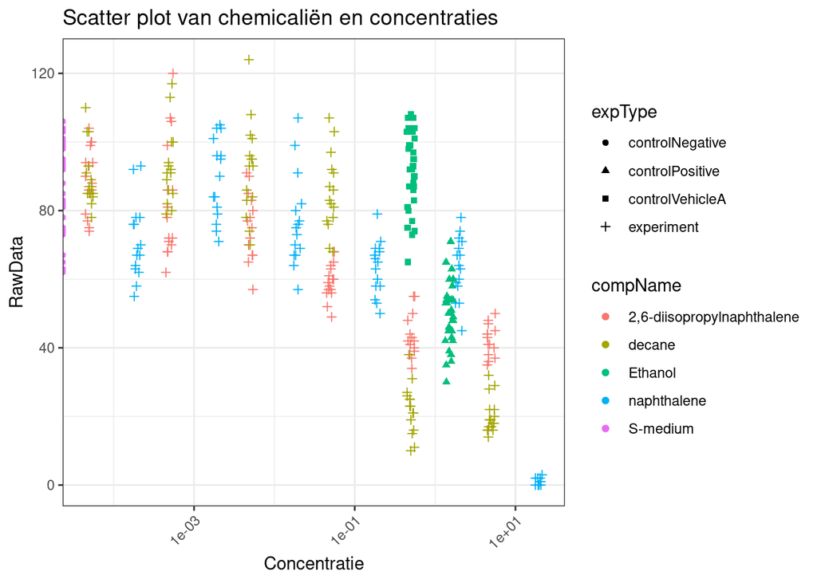

```r
ggplot(data, aes(
  x = compConcentration,
  y = RawData,
  color = compName,
  shape = expType
)) +
  geom_jitter(width = 0.05, height = 0) +
  scale_x_log10() +
  theme_bw() +
  theme(
    axis.text.x = element_text(angle = 45, hjust = 1)
  ) +
  labs(
    title = "Scatter plot van chemicaliën en concentraties",
    x = "Concentratie",
    y = "RawData"
  )
```

```r
# Voor de log10-transformatie zijn meetwaarden met concentratie 0 verwijderd uit de plot, omdat een logaritmische transformatie van 0 niet mogelijk is.
# Normaliseer de data voor de negatieve controle (controlNegative).
# Zorg ervoor dat de gemiddelde waarde voor de negatieve controle gelijk is aan 1 en dat alle andere meetwaarden zijn uitgedrukt als een fractie daarvan.
```

```r
# Maak een nieuwe scatter plot met de genormaliseerde waarden.
# gemiddelde negatieve controle
neg_mean <- mean(
  data$RawData[data$expType == "controlNegative"],
  na.rm = TRUE
)

# nieuwe tabel maken met genormliseerde data
data$NormalizedData <- data$RawData / neg_mean
```

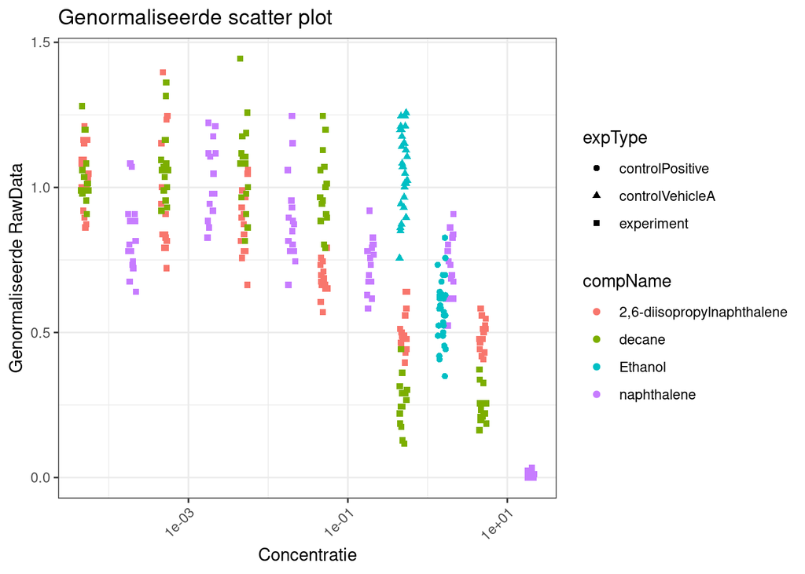

```r
plot_data <- subset(data, compConcentration > 0)

ggplot(plot_data, aes(
  x = compConcentration,
  y = NormalizedData,
  color = compName,
  shape = expType
)) +
  geom_jitter(width = 0.05, height = 0) +
  scale_x_log10() +
  theme_bw() +
  theme(
    axis.text.x = element_text(angle = 45, hjust = 1)
  ) +
  labs(
    title = "Genormaliseerde scatter plot",
    x = "Concentratie",
    y = "Genormaliseerde RawData"
  )
```

De data werd genormaliseerd door alle meetwaarden te delen door het gemiddelde van de negatieve controle (controlNegative). Hierdoor werd de gemiddelde waarde van de negatieve controle gelijk aan 1 en konden andere meetwaarden als relatieve fractie van de controle worden weergegeven. Dit maakt vergelijking tussen experimentele condities eenvoudiger.

# 9 Uitleg van de analyse

De negatieve controle (controlNegative) is de situatie zonder werkzame stof. Dit laat zien wat de normale waarde is van het aantal nakomelingen. De positieve controle is een behandeling waarvan al bekend is dat die effect heeft. Hiermee check je of het experiment goed werkt. De vehicle controle is alleen het oplosmiddel zonder stof, om te kijken of dat zelf invloed heeft op de resultaten. Deze controles zijn belangrijk om te kunnen zien of verschillen echt door de chemicaliën komen en niet door andere factoren. De data is genormaliseerd door alles te delen door het gemiddelde van de negatieve controle. Daardoor wordt de negatieve controle gelijk aan 1. Andere waarden zijn dan relatief ten opzichte hiervan. Dit maakt het makkelijker om de effecten van verschillende stoffen met elkaar te vergelijken.

# 10 vervolgonderzoek.

1. Laad het benodigde package: library(drc),
2. Gebruik de dataset zonder nul-concentraties en met genormaliseerde waarden.
3. Maak een log-logistisch model.
4. Bekijk de resultaten.
5. Bepaal de IC50 waarde.
6. Maak een plot van de dose-response curve.

#4B

gebruikte artikel: website link: https://journals.plos.org/plosone/article?id=10.1371%2Fjournal.pone.0242073 github link: https://github.com/nyiuab/NBZIMM/blob/master/tutorial/nbmms.md

#onderzoeksvraag Hoe kunnen we microbiome veranderingen over tijd goed modelleren met een statistisch model dat rekening houdt met veel nullen en herhaalde metingen?

#korte samenvatting methode en resultaten. Dit artikel onderzoekt hoe je longitudinale microbiome data het beste kunt analyseren. De onderzoeksvraag is hoe je zero-inflated en tijdsafhankelijke microbiome data statistisch goed kunt modelleren. Hiervoor ontwikkelen de auteurs een zero-inflated Gaussian mixed model (ZIGMM) met een EM-algoritme. Uit simulaties en echte datasets blijkt dat dit model beter presteert dan bestaande methoden zoals LMM en NBMM. De conclusie is dat ZIGMM efficiënter en robuuster is voor complexe microbiome data met veel nullen en herhaalde metingen.

Voor deze opdracht heb ik het artikel van PLOS ONE gebruikt over het NBZIMM model voor microbiome data. In het artikel wordt duidelijk uitgelegd wat het doel van het onderzoek is. De onderzoekers wilden een statistisch model ontwikkelen voor het analyseren van longitudinale microbiome data, waarbij rekening wordt gehouden met dingen zoals verschillen tussen metingen over tijd en variatie in sequencing data. Het artikel bevat ook een data availability statement waarin wordt uitgelegd waar de data en code beschikbaar zijn. De R code en datasets zijn gedeeld via GitHub, waardoor andere onderzoekers de analyses kunnen proberen te reproduceren. De gebruikte code en data waren beschikbaar via de GitHub repository van NBZIMM. Ook werd in het artikel beschreven waar de gebruikte data vandaan kwamen en dat het ging om microbiome studies met menselijke proefpersonen. Verder bevat het artikel professionele contactinformatie van de auteurs en affiliaties van universiteiten en onderzoeksinstellingen. Ook waren er secties aanwezig voor ethiek en funding. Hierin werd aangegeven dat er rekening is gehouden met ethische aspecten van het onderzoek en dat het onderzoek financiële ondersteuning heeft gekregen. De code beschikbaarheid van het artikel was goed, omdat zowel de R package als voorbeeldcode openbaar beschikbaar waren. Tijdens het reproduceren van de analyse liep ik wel tegen een probleem aan omdat de NBZIMM package niet meer direct via CRAN geïnstalleerd kon worden met mijn huidige versie van R. Dit kon worden opgelost door de package via GitHub te installeren. Daarna werkte de code succesvol en kon ik een deel van de analyse reproduceren. Hierdoor beoordeel ik de reproduceerbaarheid van het artikel als goed, al waren er wel kleine technische problemen tijdens het installeren van de package.

```r
# werkt niet oorsronkelijk
# install.packages("NBZIMM")

data(Romero)

otu = Romero$OTU
sam = Romero$SampleData

N = sam[, "Total.Read.Counts"]

Days = sam$GA_Days
Days = scale(Days)

Age = sam$Age
Age = scale(Age)

Race = sam$Race
preg = sam$pregnant
subject = sam[, "Subect_ID"]

y = otu[,1]

f1 = glmm.nb(
  y ~ Days + Age + Race + preg + offset(log(N)),
  random = ~ 1 | subject
)
```

```
## Computational iterations: 13
## Computational time: 0.007 minutes
```

```r
summary(f1)
```

```
## Linear mixed-effects model fit by maximum likelihood
##   Data: NULL
##   AIC BIC logLik
##    NA  NA     NA
##
## Random effects:
##  Formula: ~1 | subject
##         (Intercept)  Residual
## StdDev:    2.613723 0.9923541
##
## Variance function:
##  Structure: fixed weights
##  Formula: ~invwt
## Fixed effects:  y ~ Days + Age + Race + preg + offset(log(N))
##                  Value Std.Error  DF   t-value p-value
## (Intercept) -3.0157234 0.6253647 842 -4.822344  0.0000
## Days         0.0041136 0.0494050 842  0.083262  0.9337
## Age         -0.1088264 0.5058059  50 -0.215155  0.8305
## Race         0.3395434 0.4043499  50  0.839727  0.4051
## preg         0.6601635 1.0098754  50  0.653708  0.5163
##  Correlation:
##      (Intr) Days   Age    Race
## Days -0.007
## Age  -0.379  0.001
## Race -0.637  0.003  0.321
## preg -0.611  0.040  0.681  0.228
##
## Standardized Within-Group Residuals:
##        Min         Q1        Med         Q3        Max
## -0.7555570 -0.6178667 -0.1056515  0.1602690  8.5183847
##
## Number of Observations: 897
## Number of Groups: 54
```

Eerst worden de data ingeladen en worden de belangrijkste variabelen geselecteerd, zoals leeftijd, zwangerschap en sequencing data. Daarna wordt met de functie glmm.nb() een statistisch model gemaakt om te onderzoeken of deze factoren invloed hebben op veranderingen in de microbiome samenstelling over tijd. De structuur van de code is redelijk duidelijk en logisch opgebouwd. Er staan niet veel comments in de code zelf, maar door de volgorde is het toch goed te volgen wat er gebeurt. Daarom zou ik de leesbaarheid een 4 van de 5 geven. Voor het reproduceren van de analyse heb ik de code en data gedownload en in een nieuw R-project gezet. In het begin werkte het niet omdat de NBZIMM package niet meer via CRAN te installeren was voor mijn versie van R. Dit heb ik opgelost door de package via GitHub te installeren met remotes::install_github(). Daarna kon ik de analyse wel goed uitvoeren en een deel van het model opnieuw draaien. Uiteindelijk werkte alles zonder grote problemen. De reproduceerbaarheid is daarom ook een 4 van de 5, omdat de code en data goed beschikbaar waren, maar je wel wat technische kennis nodig hebt om installatieproblemen op te lossen.

# 11 Simpele package voor data opschoning en visualisati

De commands die gebruikt kunnen worden zijn: basic_summary(df) → geeft summary() van je dataset clean_data(df) → verwijdert rijen met NA’s (na.omit) na_count(x) → telt hoeveel NA’s er in een vector zitten quick_plot(df, x, y) → maakt snel een scatterplot met ggplot2

de package staat op deze github pagina. https://github.com/DeHeerDani/MijnRPackage

#Introductie van projecticum

In dit projecticum wordt onderzoek gedaan naar de bacterie Leptospira. Leptospira is een spiraalvormige bacterie die leptospirose kan veroorzaken, ook bekend als de ziekte van Weil (Johnson, 1996). De bacterie wordt voornamelijk overgedragen via dieren, met name ratten (“LCR - Reizigersadvisering”, n.d.), en komt vooral voor in tropischen en subtropischen gebieden zoals Afrika en Azië. Uitbraken komen vaker voor na periodes van hevige regenval. Besmetting vindt meestal plaats via contact met water dat is verontreinigd met urine van besmette dieren (“Divisie Lab: Bepalingenwijzer - Leptospira”, 2024). Symptomen variëren van koorts en hoofdpijn tot ernstigere klachten zoals gelzucht, huiduitslag en hersenvliesontsteking. Diagnose kan worden gesteld met behulp van PCR-technieken (“Leptospirose Amsterdam UMC”, 2025). Zonder behandeling kan leptospirose in ongeveer 20% van de gevallen fataal verlopen. In Nederland komt de ziekte zelden voor, met ongeveer dertig gevallen per jaar (“Leptospirose RIVM”, n.d.).

#Referenties

“Divisie Lab: Bepalingenwijzer - Leptospira.” 2024. https://www.umcutrecht.nl/bepalingenwijzer/leptospira. Johnson, Russell C. 1996. “Leptospira.” In Medical Microbiology, edited by Samuel Baron, 4th ed. Galveston (TX): University of Texas Medical Branch at Galveston. “LCR - Reizigersadvisering.” n.d. https://lcr.nl/infectieziekten/8506. Accessed December 28, 2025. “Leptospirose Amsterdam UMC.” 2025. https://www.amsterdamumc.nl/nl/patienteninformatie/leptospirose.htm. “Leptospirose RIVM.” n.d. https://www.rivm.nl/leptospirose. Accessed December 29, 2025.